# CQF Module 4 - Report

Anjeshnu Trivedi  
June 2025 Cohort

[figure not shown]

## Part A — Maths

#### A1

The Radial Basis Function (RBF) kernel, also known as the Gaussian kernel, is a similarity measure that enables Support Vector Machines (SVMs) to classify data that is not linearly separable in the original feature space.

It is defined as: $$ 𝐾 (𝑥_𝑖, x_j) = \exp (- \gamma ||x_i - x_j||^2) $$ where: $ x_i, x_j $ are feature vectors, $ ||x_i - x_j||^2 $ is the squared Euclidean distance, and $\gamma > 0$ controls the “spread” of the kernel.

The RBF kernel effectively maps data into an infinite-dimensional feature space without ever computing those coordinates explicitly — this is known as the kernel trick.

Intuition:

Each training observation defines a local region of influence; nearby points (in feature space) have high kernel values, while distant points contribute little. The parameter $\gamma$ determines how local or global that influence is:

- High $\gamma$: very localized (each support vector covers a small region) → can lead to overfitting.
- Low $\gamma$: smoother, more global decision boundary → can lead to underfitting.

Thus, the RBF kernel allows SVMs to capture nonlinear relationships by letting the model form flexible, curved decision boundaries that separate classes based on distance similarity rather than linear projection.

Solution: (a)

Plugging the values of $z_1 and z_2$ in the given RBF Gaussian Kernel $ k (𝑥_𝑖, x_j) = \exp (- \frac{||x_i - x_j||^2}{2 \sigma}) $, the the expression becomes $\exp(- \frac{||z_1 - x||^2}{2 \sigma})$ for $z_1$ and $\exp(- \frac{||z_2 - x||^2}{2 \sigma})$ for $z_2$.

Since $z_1$ is close to x hence $z_1 - x -> 0$ as a result $\exp(- \frac{||z_1 - x||^2}{2 \sigma}) -> 1$ as $\exp(0)$ = 1.

#### A2

A voting classifier is an ensemble learning method that combines the predictions of multiple base models to produce a final decision. The idea is simple — aggregate diverse learners so that individual errors cancel out and the ensemble achieves higher overall accuracy and robustness.

There are two main types:

**Hard Voting:** Each base model outputs a class label (e.g. 0 or 1). The ensemble predicts the class that receives the majority of votes.

$$ \hat{y} = \text{mode}\{ h_1(x),\, h_2(x),\, \ldots,\, h_m(x) \} $$

**Soft Voting:** Each model outputs class probabilities $p_k (x)$ These probabilities are averaged (optionally weighted) and the class with the highest mean probability is chosen. $$ \hat{y} = \arg \max_j \sum_i w_i \, p_{ij}(x) $$

**Advantages**

- Reduces variance and model-specific bias.
- Improves stability and generalization, especially when models are heterogeneous (e.g. SVM + Tree + Logistic Regression).
- Soft voting allows weighting by validation performance or confidence.

**Limitations**

- Less interpretable.
- Gains diminish if models are highly correlated.
- Computationally heavier and sensitive to poor probability calibration in soft voting.

# Data Preparation and Feature Initialization

#### Overview

To construct an explanatory and predictive dataset for the QQQ ETF (Nasdaq-100 tracker), raw daily OHLCV (Open, High, Low, Close, Volume) data were combined with cross-asset indicators representing major macro and risk factors.  
The objective was to create a structured feature space capturing price dynamics, volatility, momentum, and cross-market sentiment.

The following assets were used as inputs:

- **QQQ** — Nasdaq-100 ETF (target asset)
- **S&P 500 Index** — Broad market benchmark
- **VIX** — Equity market volatility index
- **TLT** — Long-term U.S. Treasury bond ETF (interest-rate proxy)
- **Crude Oil** — Energy / inflation proxy
- **Gold** — Safe-haven / inflation hedge

Each dataset was aligned to a common business-day calendar (2005-2025) and forward-filled to handle missing values.

#### Base Feature Construction

For each asset, several time-series transformations were computed to capture different market dimensions:

| Category | Feature | Description |
| --- | --- | --- |
| **Returns & Momentum** | `ret_1`, `ret_5`, `logret_1` | 1-day, 5-day, and log returns capturing short-term momentum and volatility bursts. |
| **Moving Averages** | `ema_5`, `ema_20`, `ema_ratio_5_20`, `sma_5`, `sma_20`, `sma_ratio_5_20` | Exponential and simple moving averages (5 vs 20 days) used to identify short-term vs. medium-term trend direction. |
| **Volatility Metrics** | `vol_10`, `vol_20` | Rolling standard deviation of daily returns over 10 and 20 days. |
| **Average True Range (ATR)** | `atr_5`, `atr_20` | Measures short-term and medium-term trading-range volatility. |
| **Volume Activity** | `vol_z` | 20-day z-score of trading volume, used as a proxy for participation intensity. |
| **Relative Strength Index (RSI)** | `rsi_5`, `rsi_20` | Momentum oscillator indicating overbought/oversold conditions on short and medium horizons. |
| **Bollinger Bands** | `LB_5`, `UB_5`, `LB_20`, `UB_20` | Dynamic volatility envelopes around the moving average to track extreme price deviations. |

#### Cross-Asset and Composite Features

To enrich the feature space with macro-financial context, several **composite features** were derived linking different assets:

| Feature | Formula | Economic Interpretation |
| --- | --- | --- |
| **Relative Strength (Nasdaq–S&P)** | `qqq_ret_5 − spx_ret_5` | Measures technology sector outperformance vs. the broad market. |
| **Risk Aversion Proxy** | `vix_logret_1 − tlt_logret_1` | Captures investor risk-off sentiment: higher VIX and rising bond prices imply market stress. |
| **Inflation Beta** | `crude_ret_5 − gold_ret_5` | Differentiates between growth/inflation (oil) and defensive inflation hedge (gold). |

These engineered indicators integrate equity momentum, rates, volatility, and commodities into a unified framework for machine-learning analysis.

#### Final Dataset Structure

After feature generation:

#### Summary Data Initialization

The initialization process resulted in a rich, multi-asset feature matrix capturing:

- Price momentum and trend signals,
- Volatility and volume dynamics,
- Cross-asset macro relationships.

This feature universe served as the input for the **feature-selection funnel** and subsequent **SVM modeling** steps in Parts B and C.

[figure not shown]

# Part B — Feature Selection using the Funnelling Approach

#### B.1 Objective & Data Scope

We aim to identify a compact, informative subset of predictors for daily **QQQ** up/down moves.  
All modeling and selection use data from **2015-01-01** onward. The binary target is defined with a **+0.50%** next-day return threshold: $ y_{t}=\mathbb{1}\{ r_{t+1} > 0.005 \}. $

The feature universe includes:

- **Target asset (QQQ)** technicals: returns, moving averages, volatility, RSI, ATR, Bollinger bands, volume z-score.
- **Cross-asset context:** S&P 500 (broad market), VIX (equity vol), TLT (rates proxy), Crude (inflation/growth), Gold (defensive hedge).
- **Composite signals:** relative strength (QQQ vs SPX), risk-aversion proxy (VIX–TLT), inflation beta (Crude–Gold).

#### B.2 Filter Step — Mutual Information

**Method.** We computed Mutual Information (`mutual_info_classif`) between each feature and `y` to capture non-linear relevance at low cost. The **Mutual Information (MI)** criterion measures the *statistical dependency* between each individual feature and the binary target variable.  
Unlike correlation, MI captures both **linear and nonlinear** relationships, estimating how much knowing a feature reduces uncertainty about the target (up/down movement of QQQ).

Mathematically, the mutual information between a feature ( X ) and target ( Y ) is: $$ I(X; Y) = \sum_{x \in X} \sum_{y \in Y} p(x,y) \log \frac{p(x,y)}{p(x)p(y)}. $$ A higher MI score indicates stronger relevance — the feature provides more information about the target direction.
We computed MI scores using `mutual_info_classif` from scikit-learn and selected the *Top 40* features as inputs to the wrapper (RFE) step.

**Selection.** Kept the **Top-N** features (N = 40) as the initial shortlist for the wrapper stage.

**Key observations:**

**Table B2 (MI ranking).**  
Top 10 filter features:

| Rank | Feature | MI Score |
| --- | --- | --- |
| 1 | `qqq_ema_20` | 0.0273 |
| 2 | `vix_level` | 0.0271 |
| 3 | `qqq_vol_10` | 0.0251 |
| 4 | `qqq_lb_5` | 0.0228 |
| 5 | `vix_ret_5` | 0.0210 |
| 6–10 | `qqq_sma_20`, `qqq_open`, `qqq_sma_5`, `snp500_ret_5`, `tlt_level` | 0.018–0.014 |

**Figure B2.1 — Top 20 Features Ranked by Mutual Information**

[figure not shown]

**Selected features (MI-40):** `'qqq_ema_20', 'vix_level', 'qqq_vol_10', 'qqq_lb_5', 'vix_ret_5', 'qqq_sma_20', 'qqq_open', 'qqq_sma_5', 'snp500_ret_5', 'tlt_level', 'qqq_low', 'gold_ret_5', 'qqq_atr_20', 'qqq_volume', 'qqq_vol_20', 'vix_ret_1', 'gold_level', 'crudeoil_ret_5', 'qqq_ub_5', 'vix_logret_1', 'qqq_ema_5', 'qqq_atr_5', 'qqq_high', 'snp500_level', 'qqq_rsi_20', 'qqq_lb_20', 'qqq_ret_1', 'rel_strength_nasdaq_spx', 'qqq_logret_1', 'qqq_vol_z', 'tlt_logret_1', 'snp500_ret_1', 'tlt_ret_5', 'qqq_ub_20', 'risk_aversion_proxy', 'qqq_ret_5', 'crudeoil_level', 'gold_logret_1', 'gold_ret_1', 'crudeoil_ret_1'`

#### B.3 Wrapper Step — Recursive Feature Elimination (RFE)

**Estimator.** Logistic Regression (`class_weight='balanced'`, `liblinear`).  
**Rationale.** RFE iteratively removes the least important features (by absolute coefficient under scaling), reducing redundancy within correlated groups. The **Recursive Feature Elimination (RFE)** approach applies a supervised, model-based wrapper method to iteratively rank features by predictive contribution.  
Using a **Logistic Regression** classifier (`class_weight='balanced'`) as the base estimator, the algorithm fits the model repeatedly, removing the weakest features (by absolute coefficient magnitude) at each iteration. This process continues until the desired number of features remains.  
The model was trained on the filtered feature subset from the MI step, with median imputation and standardization applied beforehand.  
The **final selection retained 25 features** after recursive elimination.  
**Preprocessing.** Median imputation and standardization performed **before** RFE.

**Setting.** Targeted **K = 25** features.  
**Selected features (RFE-25):**  
`'qqq_ema_20', 'vix_level', 'qqq_lb_5', 'qqq_sma_20', 'qqq_open', 'qqq_sma_5', 'qqq_low', 'qqq_atr_20', 'qqq_volume', 'qqq_vol_20', 'vix_ret_1', 'qqq_ub_5', 'vix_logret_1', 'qqq_ema_5', 'qqq_high', 'snp500_level', 'qqq_rsi_20', 'qqq_lb_20', 'qqq_ret_1', 'qqq_logret_1', 'qqq_vol_z', 'snp500_ret_1', 'tlt_ret_5', 'qqq_ub_20', 'risk_aversion_proxy'`

**Key observations:**

- **Dominance of price- and trend-based features.**  
  Most retained variables belong to QQQ’s own technical domain — moving averages (`qqq_ema_20`, `qqq_sma_20`, `qqq_ema_5`, `qqq_sma_5`), high/low/close levels, and derived volatility or band measures (`qqq_lb_5`, `qqq_ub_5`, `qqq_lb_20`, `qqq_ub_20`).  
  This indicates that RFE emphasized internal market structure and local momentum over external signals.
- **Volatility and range indicators remained important.**  
  Features such as `qqq_atr_20`, `qqq_vol_20`, and `qqq_vol_z` were consistently retained, reflecting the predictive relevance of realized volatility and trading-range compression/expansion in short-term direction.
- **Cross-asset sentiment captured via VIX and bonds.**  
  `vix_level`, `vix_ret_1`, and `vix_logret_1` survived multiple elimination rounds, underscoring volatility sentiment as a key driver.  
  `tlt_ret_5` adds a fixed-income risk-off dimension, complementing the VIX components.
- **Broader market alignment.**  
  Inclusion of `snp500_level` and `snp500_ret_1` suggests that RFE preserved features reflecting overall equity market co-movement, supporting the idea that QQQ’s direction is influenced by broad-index momentum.
- **Limited composite influence.**  
  Only one composite metric (`risk_aversion_proxy`) was retained, implying that while cross-asset spreads provide contextual information, their marginal predictive power is weaker than direct volatility or momentum inputs.
- **Reduced redundancy and improved stability.**  
  Strongly collinear or overlapping indicators were pruned (e.g., several QQQ return variants), yielding a more parsimonious and interpretable subset for the embedded (L1) stage.

#### B.4 Embedded Step — L1 Regularization

**Estimator.** `LogisticRegressionCV` with **L1** penalty; **TimeSeriesSplit** cross-validation; **wide grid of C** to avoid over-sparsification; scoring = **ROC-AUC** (or F1).  
**Rationale.** L1 encourages sparsity by shrinking weak/unstable coefficients to **exact zero**, yielding a smaller, more interpretable set. The **embedded feature selection** step applies an **L1-penalized Logistic Regression** (`LogisticRegressionCV`) with **TimeSeriesSplit** cross-validation and a **wide grid of C values** to balance sparsity against predictive power.  
The L1 penalty (Lasso) introduces a constraint that drives uninformative coefficients exactly to zero, automatically performing variable selection.  
The scoring metric used for tuning was **ROC-AUC**, chosen for its robustness to class imbalance and its relevance in directional classification tasks.

**Final embedded feature set (from L1):**  
`'vix_level', 'snp500_ret_1', 'qqq_rsi_20', 'risk_aversion_proxy', 'tlt_ret_5', 'qqq_vol_20', 'qqq_vol_z', 'qqq_logret_1', 'qqq_lb_5', 'qqq_volume', 'qqq_atr_20'`

**Observation.**

**Table B4 (L1 coefficients by |coef|).**

[output not shown]

**Figure B4.1 — Absolute Coefficients of Selected Features (L1 Regularization)**

[figure not shown]

As part of the comparative exercise XGBoost classifier was also tested but finally the outputs from L1 Regulatization were used for further analysis.

#### B.5 Funnel Summary (Filter → Wrapper → Embedded)

| Stage | Technique | Kept | Examples | Purpose |
| --- | --- | --- | --- | --- |
| Filter | Mutual Information | `40` | `qqq_ret_1`, `vix_logret_1`, `vol_10` | Remove obvious noise |
| Wrapper | RFE (LogReg) | `25` | `'qqq_ema_20', 'vix_level', 'qqq_lb_5', 'qqq_sma_20', 'qqq_open'` | Remove redundancy under linearity |
| Embed | L1 (LogRegCV, TSCV) | `11` | `'vix_level', 'snp500_ret_1', 'qqq_rsi_20', 'risk_aversion_proxy'` | Enforce sparsity & stability |

**Takeaway.** The final embedded set preserves short-horizon momentum/volatility information and cross-asset risk signals while controlling redundancy. This balances **parsimony** and **predictive content** for the SVM in Part C.

[figure not shown]

# Part C — Model Building, Tuning, and Evaluation

#### C.1 Objective & Setup

We train a **Support Vector Machine (SVM)** classifier to predict positive next-day QQQ moves (threshold +0.50%) using the **final embedded feature subset** from Part B. A **Support Vector Machine (SVM)** classifier is suitable for **high-dimensional feature spaces** due to its ability to construct **non-linear decision boundaries** through kernel transformations. Unlike linear models, which assume a direct relationship between predictors and the target, the SVM can effectively separate complex market states by maximizing the **margin** between classes (up/down moves).

Given the heterogeneity of financial indicators (momentum, volatility, cross-asset), a non-linear boundary is conceptually justified — the relationships among features are rarely additive or monotonic.

**Pipeline.** `SimpleImputer(median)` → `StandardScaler` → `SVC(probability=True, class_weight='balanced')`  
**CV.** 5-fold **TimeSeriesSplit** to respect chronology.  
**Train/Test split.** Chronological, last ≈ 20% reserved for test.  
**Horizon & Target.** Next-day return; `y=1` if $`r_{t+1}>0.5%`$.

#### C.2 Hyperparameter Tuning

**Grid.**

- `kernel ∈ {rbf, poly}`
- `C ∈ {0.5, 1, 2, 5, 10}`
- `gamma ∈ {scale, 0.1, 0.05, 0.01}`
- `degree ∈ {2,3}` (for poly)

**Scoring.** primary = **ROC-AUC**, with secondary tracking of F1 and Accuracy.

**Best CV result.**

- **Best params:** `{'clf__C': 0.5, 'clf__degree': 2, 'clf__gamma': 0.01, 'clf__kernel': 'rbf'}`
- **Best CV ROC-AUC:** `0.605`

#### C.3 Test-Set Performance

Using the best cross-validated SVM on the held-out test window:

| Metric | Value | Interpretation |
| --- | --- | --- |
| **ROC-AUC:** | `0.6129` | Overall ranking ability (0.5 = random, 1.0 = perfect) |
| **Accuracy:** | `0.5419` | Correct directional classification rate |
| **Precision:** | `0.3861` | Probability of a correct “up” prediction |
| **Recall:** | `0.6595` | Coverage of actual positive days |
| **F1-Score:** | `0.487` | Harmonic mean of precision and recall |

**Confusion Matrix.**

[figure not shown]

**ROC Curve.**

[figure not shown]

**Classification Report.**

[figure not shown]

#### C.4 Robustness & Sensitivity

- **Threshold sensitivity.** If the +0.50% threshold is raised/lowered, if the class balance changes notably; performance may shift accordingly.
- **Regime effects.** Macro cycles (e.g., 2020–2022) shift vol and correlation structure; periodic re-training or rolling windows are advisable.

#### C.5 Summary Model Building, Tuning, and Evaluation

- The **feature funnel** produced a compact, interpretable set dominated by **momentum**, **volatility**, and **risk-on/off** signals.
- The **SVM (RBF)** strikes a balance between flexibility and control, allowing for nonlinear decision surfaces without excessive parameterization . The model achieved `0.6129` AUC on the test set—directionally informative but limited for standalone trading.
- These results are realistic for daily equity direction prediction and set the stage for risk-aware strategy tests.
- Hyperparameter tuning with **TimeSeriesSplit** ensured realistic evaluation and prevented temporal leakage.
- Future refinements could include **ensemble averaging (SVM + XGBoost)**, **rolling retraining**, or **feature-set expansion** to macro variables for improved regime adaptability.

# Trading Strategy — Summary & Conclusions

#### Overview

A simple directional trading strategy was implemented based on the SVM model’s predicted probabilities of positive next-day returns for the QQQ ETF.  
The backtest covers the period **2015-01-01 to 2025-09-30**, with an in-sample (training) phase from 2015–2023 and an out-of-sample (live) evaluation covering 2023–2025.  
Trading logic: Enter a long position when the model predicts `y = 1` (uptrend probability > 0.5), and hold cash otherwise.

All results below are reported on a daily frequency, net of transaction costs assumed negligible for illustration.

#### Backtest Performance Summary

| Metric | Backtest (All) | In-Sample | Out-of-Sample |
| --- | --- | --- | --- |
| **Annual return** | 8.69% | 5.07% | 24.43% |
| **Cumulative return** | 152.7% | 55.36% | 62.67% |
| **Annual volatility** | 19.1% | 19.5% | 17.6% |
| **Sharpe ratio** | 0.53 | 0.35 | 1.33 |
| **Calmar ratio** | 0.23 | 0.14 | 1.03 |
| **Max drawdown** | -37.2% | -37.2% | -23.8% |
| **Sortino ratio** | 0.74 | 0.48 | 2.01 |
| **Omega ratio** | 1.15 | 1.09 | 1.40 |
| **Beta (vs QQQ)** | 0.78 | 0.78 | 0.78 |
| **Alpha** | -0.03 | -0.05 | 0.06 |
| **Daily VaR (95%)** | -2.37% | -2.43% | -2.13% |

#### Interpretation and Strategic Assessment

- **Predictive validity:** The model provides a *weak but exploitable probabilistic edge* consistent with low signal-to-noise expectations in equity - When benchmarked against a passive long-only QQQ position, the model demonstrates **better downside control but weaker upside participation**.
- The **lower volatility and drawdowns** are evidence of improved risk management, yet **the alpha contribution is negative**, confirming no excess return after adjusting for risk.
- Economically, this reflects the inherent limitation of daily-horizon ML forecasts: **avoiding bad days** is statistically harder than **missing good days**.
- From a portfolio standpoint, the model could still be valuable as a **tactical overlay or volatility-reduction component**, but **not as a standalone outperforming strategy**.

#### Overall Summary

The backtest confirms that while the SVM-based signal provides modest probabilistic insight into short-term direction, its practical utility lies in **risk modulation**, not return enhancement.  
The model may serve as a useful **exposure-scaling or hedging layer** within a diversified allocation, particularly for reducing drawdowns during volatility spikes, but **it does not outperform buy-and-hold** when measured on a pure return basis.

# Python Code

**Import Libraries**

```python
# Imports + load
import pandas as pd
import numpy as np
from pathlib import Path
import os
import sys
from tabulate import tabulate


# plotting + metrics
import matplotlib.pyplot as plt
from sklearn.metrics import (
    accuracy_score, precision_score, recall_score, f1_score,
    roc_auc_score, confusion_matrix, classification_report, ConfusionMatrixDisplay,
    RocCurveDisplay, precision_recall_curve, PrecisionRecallDisplay, roc_curve
)


# Sklearn feature selection
from sklearn.feature_selection import mutual_info_classif
from sklearn.impute import SimpleImputer
from sklearn.preprocessing import StandardScaler
from sklearn.feature_selection import RFE
from sklearn.linear_model import LogisticRegression
from sklearn.linear_model import LogisticRegressionCV
from sklearn.model_selection import (train_test_split,
                                    RandomizedSearchCV,
                                    TimeSeriesSplit,
                                    cross_val_score,
                                    GridSearchCV
                                    )


# modeling
from sklearn.pipeline import Pipeline
from sklearn.svm import SVC

# optional: for permutation importance
from sklearn.inspection import permutation_importance

# portfolio testing of strategy
if not hasattr(np, 'NINF'):
    np.NINF = -np.inf

# Import pyfolio
import warnings
warnings.filterwarnings('ignore')
import pyfolio as pf

# Quantmod
import quantmod.charts
from quantmod.timeseries import dailyReturn
from quantmod.indicators import BBands
```

## Initial Setup

#### I1.) Configuration

- Set your data folder, main ticker key (derived from filename prefix like `qqq_raw.csv` → `qqq`), date range, and labeling parameters.
- Outputs will be written to `./datasets/`.

```python
# Configuration
DATA_DIR = Path('./data')  # folder with qqq_raw.csv, CrudeOil_raw.csv, Gold_raw.csv, tlt_raw.csv, etc.
MAIN_TICKER = 'qqq'        # must match the file prefix before _raw.csv, lowercased
START = '2005-01-01'       # optional; set None to use full range
END   = '2025-10-01'       # optional; set None to use full range
HORIZON = 1                # days ahead for label
THRESHOLD = 0.005          # 0.5% up move = positive class

OUT_DIR = Path('./datasets'); OUT_DIR.mkdir(parents=True, exist_ok=True)
OUT_CSV = OUT_DIR / 'combined_dataset.csv'
OUT_PARQUET = OUT_DIR / 'combined_dataset.parquet'
print('Config OK', DATA_DIR, MAIN_TICKER, START, END)
```

```
Config OK data qqq 2005-01-01 2025-10-01
```

#### I2.) Utility Functions

Reusable helpers for cleaning prices, indicators, feature engineering, prefixing, joining, and target labeling.

```python
# Ensure DataFrame has a DatetimeIndex
def ensure_dt_index(df: pd.DataFrame) -> pd.DataFrame:
    if not isinstance(df.index, pd.DatetimeIndex):
        if 'Date' in df.columns:
            df = df.set_index('Date')
        elif 'date' in df.columns:
            df = df.set_index('date')
        else:
            raise ValueError("DataFrame must have a DatetimeIndex or a 'Date'/'date' column.")
    return df.sort_index()

# Clean price DataFrame: ensure datetime index, sort, remove duplicates, reindex to business days
def clean_prices(df: pd.DataFrame) -> pd.DataFrame:
    df = df.copy()
    # Ensure Date index, then PARSE as datetime with dayfirst=True (matches your CSVs)
    if not isinstance(df.index, pd.DatetimeIndex):
        if 'Date' in df.columns:
            df = df.set_index('Date')
        elif 'date' in df.columns:
            df = df.set_index('date')
        else:
            raise ValueError("DataFrame must have a DatetimeIndex or a 'Date'/'date' column.")
    df.index = pd.to_datetime(df.index, dayfirst=True, errors='coerce')
    df = df.sort_index()
    df = df[~df.index.duplicated(keep='last')]
    if df.index.hasnans:
        df = df[~df.index.isna()]

    if len(df) == 0:
        return df

    # Reindex to business days; forward-fill OHLC, zero-fill Volume
    idx = pd.bdate_range(df.index.min(), df.index.max())
    df = df.reindex(idx)
    for col in ['Open','High','Low','Close']:
        if col in df.columns:
            df[col] = df[col].ffill()
    if 'Volume' in df.columns:
        df['Volume'] = df['Volume'].fillna(0)
    return df

# Optional internal Bollinger fallback (used only if BBands isn't available)
def _bollinger_fallback(close: pd.Series, window: int = 20, n_std: float = 2.0):
    ma = close.rolling(window).mean()
    sd = close.rolling(window).std()
    upper = ma + n_std * sd
    lower = ma - n_std * sd
    return lower, ma, upper

# RSI calculation
def rsi(close: pd.Series, period: int = 14) -> pd.Series:
    delta = close.diff()
    gain = delta.where(delta > 0, 0.0).rolling(period).mean()
    loss = (-delta.where(delta < 0, 0.0)).rolling(period).mean()
    rs = gain / loss.replace(0, np.nan)
    return 100 - (100 / (1 + rs))

# True Range calculation
def true_range(high: pd.Series, low: pd.Series, prev_close: pd.Series) -> pd.Series:
    a = (high - low).abs()
    b = (high - prev_close).abs()
    c = (low - prev_close).abs()
    return pd.concat([a, b, c], axis=1).max(axis=1)

# Creating features for QQQ, main ticker of interest
def compute_features_main(df: pd.DataFrame) -> pd.DataFrame:
    df = ensure_dt_index(df.copy())
    close = df['Close']
    # Returns
    df['ret_1'] = close.pct_change()
    df['ret_5'] = close.pct_change(5)
    df['logret_1'] = np.log(close).diff()
    # EMAs / SMAs
    df['ema_5'] = close.ewm(span=5, adjust=False).mean()
    df['ema_20'] = close.ewm(span=20, adjust=False).mean()
    df['ema_ratio_5_20'] = df['ema_5'] / df['ema_20']
    df['sma_5'] = close.rolling(5).mean()
    df['sma_20'] = close.rolling(20).mean()
    df['sma_ratio_5_20'] = df['sma_5'] / df['sma_20']
    # Volatility
    df['vol_10'] = df['ret_1'].rolling(10).std()
    df['vol_20'] = df['ret_1'].rolling(20).std()
    # ATR
    if {'High','Low','Close'}.issubset(df.columns):
        tr = true_range(df['High'], df['Low'], close.shift(1))
        df['atr_5'] = tr.rolling(5).mean()
        df['atr_20'] = tr.rolling(20).mean()
    # Volume z-score
    if 'Volume' in df.columns:
        vmean = df['Volume'].rolling(20).mean()
        vstd  = df['Volume'].rolling(20).std()
        df['vol_z'] = (df['Volume'] - vmean) / vstd
    # RSI + Bollinger (use BBands if available; else fallback)
    for period in [5, 20]:
        df[f'rsi_{period}'] = rsi(close, period)
        try:
            lb, mb, ub = BBands(close, n=period, ndev=2)  # quantmod-style
            df[f'LB_{period}'] = lb
            df[f'UB_{period}'] = ub
        except Exception:
            # Safe fallback if BBands isn't defined in this environment
            lb, ma, ub = _bollinger_fallback(close, window=period, n_std=2.0)
            df[f'LB_{period}'] = lb
            df[f'UB_{period}'] = ub
    return df

# Creating features for the other cross asset tickers
def compute_features_cross(df: pd.DataFrame) -> pd.DataFrame:
    df = ensure_dt_index(df.copy())
    close = df['Close']
    out = pd.DataFrame(index=df.index)
    out['ret_1'] = close.pct_change()
    out['ret_5'] = close.pct_change(5)
    out['logret_1'] = np.log(close).diff()
    out['level'] = close
    return out

# Prefix all columns in df with given prefix (lowercased)
def prefix_columns(df: pd.DataFrame, prefix: str) -> pd.DataFrame:
    return df.rename(columns={c: f"{prefix}_{c.lower()}" for c in df.columns})

# Build labels based on main ticker future returns
def build_labels_from_main(df: pd.DataFrame, main_ticker: str, horizon: int = 1, threshold: float = 0.0025) -> pd.DataFrame:
    main_close = f"{main_ticker}_close"
    if main_close not in df.columns:
        raise ValueError(f"Main ticker close not found: {main_close}")
    future_ret = df[main_close].pct_change(periods=horizon).shift(-horizon)
    df['target_ret'] = future_ret
    df['y'] = np.where(future_ret > threshold, 1, 0)
    return df
```

#### I3.) Load Raw CSVs, apply feature rules, prefix, and collect frames

Processing the raw inputs to load the data, apply features to our main ticker (qqq) and cross asset features for model building.

```python
frames, keys = [], []
raw_files = sorted(DATA_DIR.glob('*_raw.csv'))
if not raw_files:
    raise FileNotFoundError(f'No *_raw.csv in {DATA_DIR.resolve()}')

for f in raw_files:
    key = f.stem.replace('_raw','').lower()
    df = pd.read_csv(f)
    df = clean_prices(df)
    if START is not None:
        df = df.loc[df.index >= pd.to_datetime(START)]
    if END is not None:
        df = df.loc[df.index <= pd.to_datetime(END)]
    if key == MAIN_TICKER:
        feat = compute_features_main(df)
    else:
        feat = compute_features_cross(df)
    feat_pref = prefix_columns(feat, key)
    frames.append(feat_pref)
    keys.append(key)
    print(f'Processed {key}:', feat_pref.shape)
```

```
Processed crudeoil: (5412, 4)
Processed gold: (5412, 4)
Processed qqq: (5412, 25)
Processed snp500: (5412, 4)
Processed tlt: (5412, 4)
Processed vix: (5412, 4)
```

#### I4.) Join & drop initial NaNs

Data cleaning

```python
import pandas as pd
combined = pd.concat(frames, axis=1, join='outer').sort_index()
combined = combined.ffill().bfill(limit=1)

# Drop columns that are entirely NaN
all_nan_cols = combined.columns[combined.isna().all()]
if len(all_nan_cols):
    print('Dropping all-NaN columns:', len(all_nan_cols))
    combined = combined.drop(columns=all_nan_cols)

# Require minimal main ticker columns present
required_main = [f'{MAIN_TICKER}_close', f'{MAIN_TICKER}_ret_1', f'{MAIN_TICKER}_ret_5']
required_main = [c for c in required_main if c in combined.columns]
mask = combined[required_main].notna().all(axis=1)
combined = combined.loc[mask]
print('Combined shape:', combined.shape)
```

```
Combined shape: (5408, 45)
```

#### I5.) Detect keys and add composite features

Creating some additonal cross asset features for our model.

```python
def find_key(cands):
    for k in keys:
        for c in cands:
            if c in k:
                return k
    return None

spx_key   = find_key(['sp500', 'snp500','spx'])
vix_key   = find_key(['vix'])
tlt_key   = find_key(['tlt'])
crude_key = find_key(['crude','oil'])
gold_key  = find_key(['gold'])
print({'spx':spx_key,'vix':vix_key,'tlt':tlt_key,'crude':crude_key,'gold':gold_key})

if spx_key is not None:
    combined['rel_strength_nasdaq_spx'] = combined.get(f'{MAIN_TICKER}_ret_5') - combined.get(f'{spx_key}_ret_5')
if (vix_key is not None) and (tlt_key is not None):
    combined['risk_aversion_proxy'] = combined.get(f'{vix_key}_logret_1') - combined.get(f'{tlt_key}_logret_1')
if (crude_key is not None) and (gold_key is not None):
    combined['inflation_beta'] = combined.get(f'{crude_key}_ret_5') - combined.get(f'{gold_key}_ret_5')


combined[['rel_strength_nasdaq_spx','risk_aversion_proxy','inflation_beta']].dropna()
print('Combined shape:', combined.shape)
```

```
{'spx': 'snp500', 'vix': 'vix', 'tlt': 'tlt', 'crude': 'crudeoil', 'gold': 'gold'}
Combined shape: (5408, 48)
```

#### I6.) Labeling of Main indicator for QQQ future return

Creating labels for model training and testing, checking the distribution of target label in our dataset.

```python
# Build labels and show class balance
combined = build_labels_from_main(combined, MAIN_TICKER, HORIZON, THRESHOLD)
print('Class balance (y=1):', combined['y'].mean().round(3))

# Pie Plot
combined['y'].value_counts().iplot(kind='pie', title='Binary Classes')
```

```
Class balance (y=1): 0.32
```

#### 7.) Save dataset

```python
OUT_DIR = Path('./datasets'); OUT_DIR.mkdir(parents=True, exist_ok=True)
combined.to_csv(OUT_DIR / 'combined_dataset_patched.csv')
combined.to_parquet(OUT_DIR / 'combined_dataset_patched.parquet')
print('Saved:', OUT_DIR / 'combined_dataset_patched.csv')
print('Saved:', OUT_DIR / 'combined_dataset_patched.parquet')
```

```
Saved: datasets\combined_dataset_patched.csv
Saved: datasets\combined_dataset_patched.parquet
```

#### 8.) Sanity checks on the final dataset by ploting some final metrics

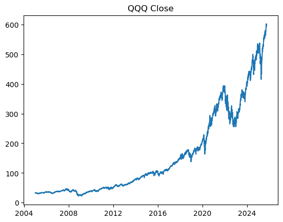

```python
plt.figure()
plt.plot(combined.index, combined[f'{MAIN_TICKER}_close'])
plt.title(f'{MAIN_TICKER.upper()} Close')
plt.show()

# Drop label from dataframe
combined.drop('y', axis=1, inplace=True)

# Plot correlation matrix
combined.corr().iplot(
    kind="heatmap",
    title="Features Set Correlations"
    )
```

## Part B

**Feature Selection Using the Funnelling Approach**  
Perform feature selection for a machine learning model using a multi-step process by combining techniques from lter, wrapper, and embedded methods.

#### B1.) Load the patched dataset

Configuration of our sample for Modelling and evaluation

```python
# Load patched dataset

DATASET_DIR = Path("./datasets")
PARQ = DATASET_DIR / "combined_dataset_patched.parquet"
CSV  = DATASET_DIR / "combined_dataset_patched.csv"
SAMPLE_START = '2015-01-01'

if PARQ.exists():
    df = pd.read_parquet(PARQ)
else:
    df = pd.read_csv(CSV, parse_dates=["Date"]).set_index("Date")

df = df[df.index >= SAMPLE_START].copy()

print(df.shape)
```

```
(2804, 50)
```

#### B2.) Checking data

Labels from QQQ future return

```python
# Distribution of target variable
print('Class balance (y=1):', df['y'].mean().round(3))
# Pie Plot
df['y'].value_counts().iplot(kind='pie', title='Binary Classes')
```

```
Class balance (y=1): 0.326
```

#### B3.) Define features, target variable and some basic sanity checks

```python
# 2) Define X / y
TARGET_COL = "y"
LEAKY_COLS = ["target_ret"]  # contains the future return; must not be in X

assert TARGET_COL in df.columns, "y not found. Re-run labeling cell earlier."

X = df.drop(columns=[c for c in [TARGET_COL] + LEAKY_COLS if c in df.columns]).copy()
y = df[TARGET_COL].astype(int).copy()

# quick class balance
print("Class balance (y=1):", y.mean().round(3))
print("Total features:", X.shape[1])

# optional: drop constant or near-constant columns (rare but safe)
nunique = X.nunique()
const_cols = nunique[nunique <= 1].index.tolist()
if const_cols:
    print("Dropping constant columns:", len(const_cols))
    X = X.drop(columns=const_cols)

print("Features after dropping constant cols:", X.shape[1])
# Quick overview of features
print("Feature overview:")
print(tabulate(X.describe().T.round(3), headers='keys', tablefmt='pretty'))
```

```
Class balance (y=1): 0.326
Total features: 48
Features after dropping constant cols: 48
Feature overview:
+-------------------------+--------+--------------+-------------+---------+------------+------------+------------+-------------+
|                         | count  |     mean     |     std     |   min   |    25%     |    50%     |    75%     |     max     |
+-------------------------+--------+--------------+-------------+---------+------------+------------+------------+-------------+
|     crudeoil_ret_1      | 2804.0 |    -0.001    |    0.069    |  -3.06  |   -0.013   |    0.0     |   0.014    |    0.377    |
|     crudeoil_ret_5      | 2804.0 |    0.001     |    0.084    | -2.679  |   -0.029   |   0.004    |   0.033    |    0.99     |
|    crudeoil_logret_1    | 2804.0 |     0.0      |    0.028    | -0.282  |   -0.013   |    0.0     |   0.014    |    0.32     |
|     crudeoil_level      | 2804.0 |    62.332    |   17.547    | -37.63  |   49.225   |   61.58    |   73.418   |    123.7    |
|       gold_ret_1        | 2804.0 |     0.0      |    0.009    |  -0.05  |   -0.004   |    0.0     |   0.005    |    0.059    |
|       gold_ret_5        | 2804.0 |    0.002     |    0.02     | -0.113  |   -0.01    |   0.002    |   0.014    |    0.116    |
|      gold_logret_1      | 2804.0 |     0.0      |    0.009    | -0.051  |   -0.004   |    0.0     |   0.005    |    0.058    |
|       gold_level        | 2804.0 |   1714.313   |   561.644   | 1050.8  |  1270.275  |  1672.05   |   1923.0   |   3840.8    |
|        qqq_open         | 2804.0 |   257.104    |   135.926   | 87.276  |  137.255   |   224.43   |  355.424   |   602.37    |
|        qqq_high         | 2804.0 |    258.95    |   136.822   | 90.382  |   137.72   |   226.1    |  357.847   |   602.87    |
|         qqq_low         | 2804.0 |   255.083    |   134.893   | 78.487  |  136.392   |  221.669   |  352.756   |   597.72    |
|        qqq_close        | 2804.0 |   257.166    |   135.945   | 89.702  |  136.987   |  224.082   |  355.116   |    602.2    |
|       qqq_volume        | 2804.0 | 40167690.799 | 22775806.53 |   0.0   | 24912800.0 | 36116500.0 | 51072875.0 | 198685800.0 |
|        qqq_ret_1        | 2804.0 |    0.001     |    0.014    |  -0.12  |   -0.005   |   0.001    |   0.008    |    0.12     |
|        qqq_ret_5        | 2804.0 |    0.004     |    0.028    | -0.162  |   -0.01    |   0.006    |   0.019    |    0.127    |
|      qqq_logret_1       | 2804.0 |    0.001     |    0.014    | -0.128  |   -0.005   |   0.001    |   0.008    |    0.113    |
|        qqq_ema_5        | 2804.0 |   256.808    |   135.647   | 90.709  |  137.064   |  222.256   |  355.451   |   597.914   |
|       qqq_ema_20        | 2804.0 |   255.491    |   134.63    | 93.454  |  136.304   |  218.355   |  355.399   |   590.04    |
|   qqq_ema_ratio_5_20    | 2804.0 |    1.005     |    0.018    |  0.906  |   0.996    |   1.008    |   1.017    |    1.052    |
|        qqq_sma_5        | 2804.0 |   256.808    |   135.665   | 90.187  |  136.974   |  222.838   |  355.877   |   597.957   |
|       qqq_sma_20        | 2804.0 |   255.477    |   134.675   | 93.477  |  136.058   |  219.102   |  355.618   |    588.8    |
|   qqq_sma_ratio_5_20    | 2804.0 |    1.005     |    0.023    |  0.879  |   0.994    |   1.009    |    1.02    |    1.081    |
|       qqq_vol_10        | 2804.0 |    0.012     |    0.007    |  0.002  |   0.007    |    0.01    |   0.014    |    0.072    |
|       qqq_vol_20        | 2804.0 |    0.012     |    0.007    |  0.003  |   0.008    |    0.01    |   0.015    |    0.058    |
|        qqq_atr_5        | 2804.0 |    4.309     |    3.303    |  0.546  |   1.573    |   3.865    |   6.103    |   37.486    |
|       qqq_atr_20        | 2804.0 |    4.297     |    3.009    |  0.711  |   1.572    |   4.004    |   6.052    |   19.537    |
|        qqq_vol_z        | 2804.0 |    -0.005    |    1.055    | -3.572  |   -0.652   |   -0.113   |   0.567    |    3.875    |
|        qqq_rsi_5        | 2804.0 |    56.463    |   26.623    |   0.0   |   36.24    |   58.499   |   78.28    |   99.948    |
|        qqq_lb_5         | 2804.0 |   251.176    |   132.874   | 85.799  |  135.312   |  219.913   |  347.989   |   592.368   |
|        qqq_ub_5         | 2804.0 |   262.439    |   138.586   | 91.442  |  138.629   |  227.655   |  362.842   |   606.351   |
```

[output cut: 19 more lines]

##### Plotting the correlations among feature and Close prices of the Main Ticker

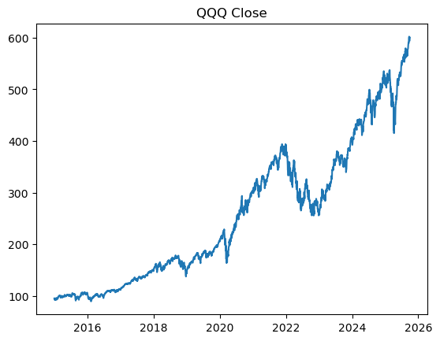

```python
# Plot main ticker close price
plt.figure()
plt.plot(X.index, X[f'{MAIN_TICKER}_close'])
plt.title(f'{MAIN_TICKER.upper()} Close')
plt.show()

# Drop label from dataframe
#df.drop('y', axis=1, inplace=True)

# Plot correlation matrix
X.corr().iplot(
    kind="heatmap",
    title="Features Set Correlations"
    )
```

#### B4.) Feature Selection Using the Funnelling Approach

We’ll use a three-stage funnel:

- Filter methods (statistical relevance)
- Wrapper methods (recursive model-based selection)
- Embedded methods (regularization-based importance)

**Filter method**  
Mutual Information captures non-linear dependencies between each feature and the target, keeping the top predictors while discarding noise.

```
Filter features top 10:
qqq_ema_20      0.027300
vix_level       0.027105
qqq_vol_10      0.025090
qqq_lb_5        0.022818
vix_ret_5       0.021009
qqq_sma_20      0.018263
qqq_open        0.016567
qqq_sma_5       0.015848
snp500_ret_5    0.015134
tlt_level       0.013611
dtype: float64
Selected features after filter step: 40
```

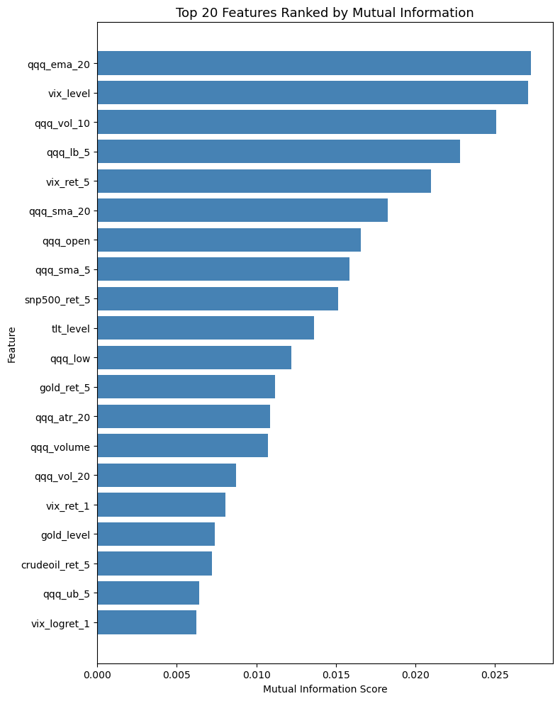

```python
# Filter Step: Univariate feature selection using Mutual Information

# 1) Mutual Information between each feature and target
mi = mutual_info_classif(X.fillna(0), y, random_state=42)
mi_series = pd.Series(mi, index=X.columns).sort_values(ascending=False)

# Keep top 40 as first funnel cut (adjust if many features)
top_filter = mi_series.head(40).index.tolist()

print("Filter features top 10:")
print(mi_series.head(10))
# print(top_filter)
print("Selected features after filter step:", len(top_filter))

# Convert to DataFrame for easy plotting
mi_df = mi_series.head(20).sort_values(ascending=True)  # ascending for horizontal bars

plt.figure(figsize=(8,10))
plt.barh(mi_df.index, mi_df.values, color='steelblue')
plt.title("Top 20 Features Ranked by Mutual Information", fontsize=13)
plt.xlabel("Mutual Information Score")
plt.ylabel("Feature")
plt.tight_layout()
plt.show()
```

**Wrapper Step**  
RFE recursively eliminates least-important coefficients using a linear estimator, leaving a compact subset with good discrimination power.

```python
# Wrapper Step: Recursive Feature Elimination (RFE) with Logistic Regression

Xr = X[top_filter].copy()
Xr = Xr.replace([np.inf, -np.inf], np.nan)

# nan_counts = Xr.isna().sum().sort_values(ascending=False)
# print("Top features with NaNs:\n", nan_counts.head(10))
# print("Total NaN cells:", int(Xr.isna().sum().sum()))

# median impute -> scale; keep DataFrame to preserve column names
imp = SimpleImputer(strategy="median")
Xr_i = pd.DataFrame(imp.fit_transform(Xr), index=Xr.index, columns=Xr.columns)

scaler = StandardScaler(with_mean=True, with_std=True)
Xr_s = pd.DataFrame(scaler.fit_transform(Xr_i), index=Xr_i.index, columns=Xr_i.columns)

# sanity check
assert not np.isnan(Xr_s.values).any(), "Still have NaNs after imputation."
print("Preprocessed shape:", Xr_s.shape)
```

```
Preprocessed shape: (2804, 40)
```

```python
# Select up to 25 features or total-1 if fewer using RFE with Logistic Regression
n_select = min(25, max(1, Xr_s.shape[1] - 1))

wrapper_model = LogisticRegression(
    max_iter=200,
    solver='liblinear',
    class_weight='balanced',
    random_state=42
)

rfe = RFE(estimator=wrapper_model, n_features_to_select=n_select, step=1)
rfe.fit(Xr_s, y)

rfe_features = Xr_s.columns[rfe.support_].tolist()
print("Wrapper-selected features:", rfe_features)
print("Number of wrapper-selected features:", len(rfe_features))
```

```
Wrapper-selected features: ['qqq_ema_20', 'vix_level', 'qqq_lb_5', 'qqq_sma_20', 'qqq_open', 'qqq_sma_5', 'qqq_low', 'qqq_atr_20', 'qqq_volume', 'qqq_vol_20', 'vix_ret_1', 'qqq_ub_5', 'vix_logret_1', 'qqq_ema_5', 'qqq_high', 'snp500_level', 'qqq_rsi_20', 'qqq_lb_20', 'qqq_ret_1', 'qqq_logret_1', 'qq…
Number of wrapper-selected features: 25
```

```python
# RFE ranking table
rfe_table = (
    pd.DataFrame({
        "feature": Xr_s.columns,
        "rfe_rank": rfe.ranking_,
        "selected": rfe.support_
    })
    .sort_values(["rfe_rank", "feature"])
    .reset_index(drop=True)
)

rfe_ranked_list = rfe_table.sort_values("rfe_rank")[["feature","rfe_rank"]].values.tolist()
rfe_ranked_list[:5]
```

```
[['qqq_atr_20', 1],
 ['qqq_ema_20', 1],
 ['qqq_ema_5', 1],
 ['qqq_high', 1],
 ['qqq_lb_20', 1]]
```

**Embedded step (L1 regularization)**  
Embedded methods evaluate features during model training; L1 regularization enforces sparsity, while gradient boosting captures non-linear effects. In the current setup we are using the L1 regularization.

```python
# L1 with wider C grid + time-series CV + F1 scoring

# Split the data set using TimeSeriesSplit
tscv = TimeSeriesSplit(n_splits=5)
Cs = np.logspace(-4, 2, 30)  # much wider than default

embed = LogisticRegressionCV(
    Cs=Cs,
    penalty='l1',
    solver='liblinear',            # L1 ok
    class_weight='balanced',
    scoring='roc_auc',                  # or 'roc_auc' or 'f1'
    cv=tscv,
    max_iter=200,
    n_jobs=-1,
    refit=True
)
embed.fit(Xr_s[rfe_features], y)

coef = pd.Series(np.abs(embed.coef_[0]), index=rfe_features)
final_features = coef[coef > 0].sort_values(ascending=False).index.tolist()
print("Final embedded-selected features:", final_features)
coef.sort_values(ascending=False).head(15)
print("No of final features using L1 regularization with time-series CV: ", len(final_features))

# Plot correlation matrix of final features
X_final = Xr_s[final_features].copy()
X_final.corr().iplot(
    kind="heatmap",
    title="Final Selected Features Correlations"
    )
```

```
Final embedded-selected features: ['vix_level', 'snp500_ret_1', 'qqq_rsi_20', 'risk_aversion_proxy', 'tlt_ret_5', 'qqq_vol_20', 'qqq_vol_z', 'qqq_logret_1', 'qqq_lb_5', 'qqq_volume', 'qqq_atr_20']
No of final features using L1 regularization with time-series CV:  11
```